# RPG 599 Part 5

Han Yu, Department of Biostatistics and Bioinformatics

04/05/2022

```r
library("glmnet")
library("doBy")
library("ggplot2")
library("ggsci")
source("MERGE.R")
source("ENet_CV.R")
```

### Data processing

Prepare the gene expression data.

```r
df_exp_0 <- read.csv(file = "patient_expression.csv", stringsAsFactors = FALSE)
df_exp_0 <- subset(df_exp_0, !is.na(UID) & UID!="")
df_exp_1 <- summaryBy(.~UID, df_exp_0, FUN = "mean", keep.names = TRUE)
exp_mat <- as.matrix(df_exp_1[, -(1:2)])
rownames(exp_mat) <- df_exp_1$UID
colnames(exp_mat)[23] <- "AML062"
```

Prepare the drug response data.

```r
df_auc_0 <- read.csv(file = "patient_auc.csv", stringsAsFactors = FALSE)
df_auc_1 <- subset(df_auc_0, X53.drugs == 1)
auc_mat <- as.matrix(df_auc_1[, -(1:2)])
rownames(auc_mat) <- df_auc_1$UID
colnames(auc_mat) <- gsub("\\.", "", colnames(auc_mat))
auc_mat_1 <- t(auc_mat)
```

Prepare the gene feature data.

```r
df_feature_0 <- read.csv(file = "driver_feature.csv", stringsAsFactors = FALSE)
colnames(df_feature_0)[4] <- "ExpressionHub"
colnames(df_feature_0)[6] <- "CNV"
duplicates <- duplicated(df_feature_0$GENE)
df_feature_1 <- df_feature_0[!duplicates, ]
feature_mat <- df_feature_1[, 3:7]
rownames(feature_mat) <- df_feature_1$GENE
```

We select the genes that are present in both gene expression and gene feature data. We further ensure each row in these two matrices corresponds to the same gene.

```r
genes_overlap <- intersect(rownames(exp_mat), rownames(feature_mat))
exp_mat <- exp_mat[genes_overlap, ]
feature_mat <- feature_mat[genes_overlap, ]
exp_mat_1 <- t(exp_mat)
```

Check the dimensions of the data. The expression matrix is for 30 patients $\times$ 16839 genes. The AUC matrix is for 30 patients $\times$ 53 drugs. The gene feature matrix is for 16839 genes $\times$ 5 gene features.

```r
dim(exp_mat_1)
```

```
## [1]    30 16839
```

```r
dim(auc_mat_1)
```

```
## [1] 30 53
```

```r
dim(feature_mat)
```

```
## [1] 16839     5
```

```r
exp_mat_1[1:5, 1:5]
```

```
##            A1BG     A1CF    A2LD1      A2M     A2ML1
## AML017 5.606349 3.946275 5.322208 8.105169 0.8207235
## AML030 5.466612 2.236413 4.668564 7.251890 3.4615571
## AML044 5.759834 4.003126 4.922140 6.819131 3.6267303
## AML056 5.326025 4.529589 4.680496 5.398818 3.8518424
## AML059 5.024122 3.226178 4.532513 4.246456 2.8651241
```

```r
auc_mat_1[1:5, 1:5]
```

```
##         ABT-263  ABT-737 Acrichine  AP24534  ARQ-197
## AML017 642.6574 549.2011  841.3301 612.7944 681.0097
## AML030 570.4069 668.4196  822.1050 671.3002 747.5600
## AML044 535.6010 480.7256  642.6549 455.9550 654.1737
## AML056 376.6334 249.2783  714.0790 404.3379 685.6413
## AML059 410.2401 265.9020  755.7353 363.0431 567.9959
```

```r
feature_mat[1:5, 1:5]
```

```
##       Mutation ExpressionHub Regulator CNV meEthylation
## A1BG         0             0         0   1     0.971318
## A1CF         0             0         1   0     0.842760
## A2LD1        0             0         0   0     0.000000
## A2M          0             0         0   0     0.804458
## A2ML1        0             0         0   0     0.898664
```

For demonstration purpose, we arbitrarily selected the first 15 patients as the training set and the remaining patients as the test set. Before modeling, the data needs to be starndardized to have unit variances. Note that the MERGE algorithm requires genes at the rows and patients at the columns, so the matrix needs to be transposed using t().

```r
exp_mat_training <- t(scale(exp_mat_1[1:15, ]))
auc_mat_training <- t(scale(auc_mat_1[1:15, ]))
exp_mat_test <- t(scale(exp_mat_1[16:30, ]))
auc_mat_test <- t(scale(auc_mat_1[16:30, ]))
feature_mat <- scale(feature_mat)
```

### Fit the MERGE model

For implementation of the MERGE algorithm, we just set the hyperparameter $\lambda=20$ for convenience. This was selected in the article by cross-validation. In practice, we need to select $\lambda$ by implementing the cross-validation for each data splitting.

```r
merge_fit <- MERGE(x_norm = exp_mat_training, y_norm = auc_mat_training,
                   Fnorm = feature_mat, lambda0 = 20, init='zero')
```

```
## [1] "iter = 1 min = 16.6713247501278  max = 21.1729487737201"
## [1] "iter = 2 min = 15.2537322352684  max = 21.6476099785566"
## [1] "iter = 3 min = 14.6188132707543  max = 21.8372285239041"
## [1] "iter = 4 min = 14.3274016063736  max = 21.9128490400195"
## [1] "iter = 5 min = 14.192382715289  max = 21.9430250757797"
## [1] "iter = 6 min = 14.1294514286538  max = 21.955108000643"
## [1] "iter = 7 min = 14.1001092114501  max = 21.959961247799"
## [1] "iter = 8 min = 14.0864155624627  max = 21.9619189504822"
## [1] "iter = 9 min = 14.080022785105  max = 21.9627124131761"
## [1] "iter = 10 min = 14.0770311817336  max = 21.9630362939642"
```

Through the MERGE algorithm, we obtain the matrix of weights $W$. The element in row $i$ and column $j$, which is $w_{ij}$, corresponds to the association between the $i$th gene and $j$th drug.

```r
dim(merge_fit$W)
```

```
## [1] 16839    53
```

The article did not provide the implementation for making predictions. A straightforward way to make predictions of the response to drug $j$ of patient $n$ is to calculate a weighted sum
$$\hat{y}_{jn}^\prime = \sum_iw_{ij}x_{jn}$$
Since we want to calculate the standardized response, we need to standardize the predicted response to unit variance. To do this, we divide the $\hat{y}_{jn}^\prime$ by the sqare root of its variance (standard error). The variance of $\hat{y}_{jn}^\prime$ can be estimated by the following

$$Var(\hat{y}_{jn}^\prime) = Var(\sum_iw_{ij}x_{jn}) = \sum_iw_{ij}^2Var(x_{jn})+2\sum_{j,k<j}w_{ij}w_{ik}Cov(x_{jn}, x_{kn})$$
This can be simplified uisng matrix operations,

$$Y^\prime_n = WX_n$$
$$Var(Y^\prime_n) = W^T\Sigma W$$
where $\Sigma$ is the covariance matrix of $X$, and $W^T$ is the transpose of $W$ (switching rows and columns). The final prediction is

$$\hat{y}_{jn}= \hat{y}_{jn}^\prime/\sqrt{Var(\hat{y}_{jn}^\prime)}$$

Implementation of the prediction step is given below.

```r
pred <- t(merge_fit$W) %*% exp_mat_test
cor_mat <- cor(t(exp_mat_training))
var_vec <- t(merge_fit$W) %*% cor_mat %*% merge_fit$W
var_vec_1 <- diag(var_vec)
sd_vec <- sqrt(var_vec_1)
pred <- pred/sd_vec
```

We can calculate the Spearman correlation coefficient for each drug and calculate the mean correlation coefficient. The distribution of the correlations is shown as a histogram.

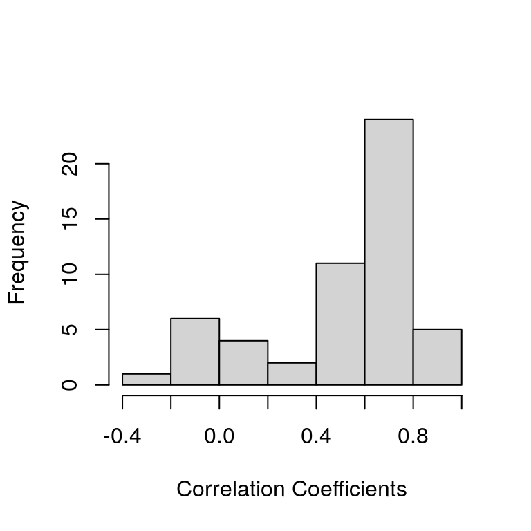

```r
cor_vec <- c()
for (i in 1:53) {
  cor_vec[i] <- cor(pred[i,], auc_mat_test[i,], method = "spearman")
}

hist(cor_vec, xlab = "Correlation Coefficients", main="")
```

```r
mean(cor_vec)
```

```
## [1] 0.5100335
```

We can further visualize the agreement between predicted and observed responses of the first drug in the test set.

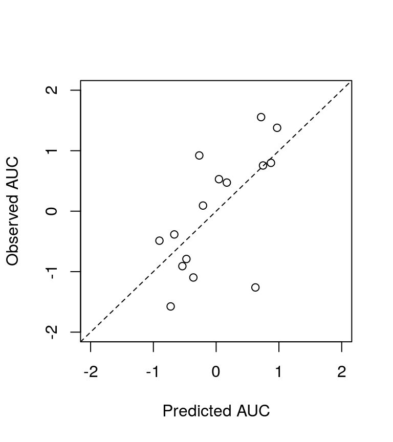

```r
plot(pred[1,], auc_mat_test[1,], xlim=c(-2, 2), ylim=c(-2,2),
     xlab="Predicted AUC", ylab="Observed AUC")
abline(a=0, b=1, lty=2)
```

### Elastic Net

Next we implement the elastic net regression. Firstly, a set of hyperparameters $\alpha$ and $\lambda$ were generated for random search. The generated hyperparameters are visualized below.

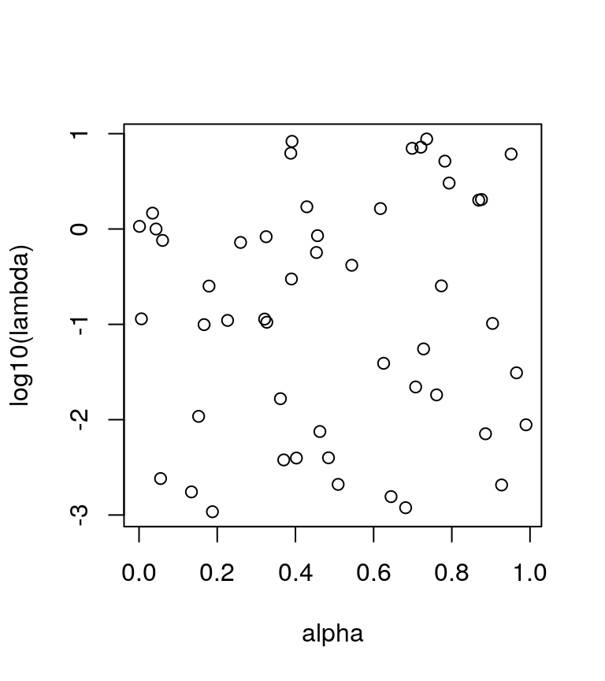

```r
set.seed(12345)
alpha <- runif(50, 0, 1)
lambda <- 10^runif(50, -3, 1)
plot(alpha, log10(lambda))
```

We use the cv_elasticnet function to perform the cross-validation, and then use the selected hyperparameters to build the model. Note that for elastic net we will build a separate model for each drug. The prediction performence of elastic net is not as good as MERGE, at least for the current data split.

```r
exp_mat_training_1 <- t(exp_mat_training)
exp_mat_test_1 <- t(exp_mat_test)

cor_vec_enet <- c()
set.seed(12345)
for (i in 1:53) {
  y_train <- auc_mat_training[i,]
  y_test <- auc_mat_test[i,]
  cv_en_fit <- cv_elasticnet(exp_mat_training_1, y_train, alpha, lambda, nfolds = 5)
  sel <- which.max(cv_en_fit$corrs)

  glmnet_fit <- glmnet(exp_mat_training_1, y_train, alpha = alpha[sel], lambda = lambda[sel])
  glm_pred <- predict(glmnet_fit, exp_mat_test_1)[,1]

  cor_vec_enet[i] <- cor(glm_pred, y_test, method = "spearman")
}

cor_vec_enet[is.na(cor_vec_enet)] <- 0
mean(cor_vec_enet)
```

```
## [1] 0.3395123
```

### Experiment

Next, we want to see if we can improve the model by only using the hub genes. First, we select the genes with top 20% hubness.

```r
gene_hub <- which(feature_mat[, 2]>quantile((feature_mat[, 2]), 0.8))
```

Here, we only use the hub genes to build the elastic net models. The model performance is slightly improved.

```r
cor_vec_hub <- c()
set.seed(12345)
for (i in 1:53) {
  y_train <- auc_mat_training[i,]
  y_test <- auc_mat_test[i,]
  cv_en_fit <- cv_elasticnet(exp_mat_training_1[, gene_hub], y_train, alpha, lambda, nfolds = 5)
  sel <- which.max(cv_en_fit$corrs)

  glmnet_fit <- glmnet(exp_mat_training_1[, gene_hub], y_train, alpha = alpha[sel], lambda = lambda[sel])
  glm_pred <- predict(glmnet_fit, exp_mat_test_1[, gene_hub])[,1]

  cor_vec_hub[i] <- cor(glm_pred, y_test, method = "spearman")
}

cor_vec_hub[is.na(cor_vec_hub)] <- 0
mean(cor_vec_hub)
```

```
## [1] 0.4011889
```

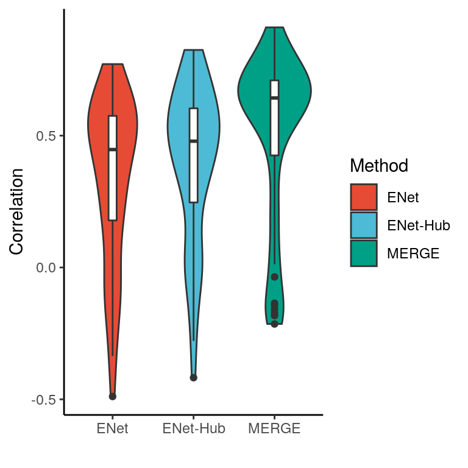

```r
df_1 <- data.frame(Method = "MERGE", Corr = cor_vec, Drug = rownames(auc_mat_training))
df_2 <- data.frame(Method = "ENet", Corr = cor_vec_enet, Drug = rownames(auc_mat_training))
df_3 <- data.frame(Method = "ENet-Hub", Corr = cor_vec_hub, Drug = rownames(auc_mat_training))
df_plot <- rbind(df_1, df_2)
df_plot <- rbind(df_plot, df_3)
ggplot(df_plot, aes(x=Method, y=Corr, fill=Method)) +
  geom_violin(trim=TRUE) +
  geom_boxplot(width=0.1, fill="white") +
  labs(x="", y = "Correlation") +
  scale_fill_npg() +
  theme_classic()
```